# Simple Linear Regression

Week 2

Published

January 16, 2025

# Before we start

- Download the data
- Organize your directory

[Download script](https://artur-baranov.github.io/nu-ps405-ds/scripts/ps405-d_2.qmd)

[Download data](https://artur-baranov.github.io/nu-ps405-ds/data/WHR.csv)

# Review of the Previous Session

Let’s refresh what we did last week.

**Review**

First, load the `tidyverse` library

```r
library(tidyverse)
```

Then, load the V-Dem data

```r
load(url("https://github.com/vdeminstitute/vdemdata/raw/6bee8e170578fe8ccdc1414ae239c5e870996bc0/data/vdem.RData"))
```

You are interested in corruption in various geographical regions. Select year (`year`), region (`e_regionpol_7C`) and corruption (`v2x_corr`) variables from the `vdem` dataset.

```r
corruption_data = ... %>%
  ...(year, ..., v2x_corr)
```

As we are working with the V-Dem data, let’s rename variables so it’s more straightforward.

```r
corruption_data = corruption_data ...
  ...(region = e_regionpol_7C,
      corruption = ...)
```

Calculate the average of the `corruption` variable. Don’t forget about the `na.rm = TURE` argument!

```r
...
```

Using `group_by()` and `summarize()` calculate the average corruption for all regions in the dataset.

```r
corruption_data ...
  (...) %>%
  ...(average = ...(..., na.rm = T))
```

Lastly, let’s see the distributions of corruption across regions. Draw a boxplot below with `region` variable on the X axis, and `corruption` variable on the Y axis.

```r
ggplot(data = corruption_data) +
  ...(aes(x = ..., y = ...))
```

Something is wrong, right? We haven’t checked the classes of the variables, and apparently the `region` variable has to be changed. Let’s check it’s class first.

```r
...(corruption_data$...)
```

What class should it be? Let’s recode it directly on the plot.

```r
...(...) +
  geom_boxplot(aes(x = ...(region), y = ...))
```

# Agenda for Today

- Clearing the environment
- Loading CSV data to R
- Building a simple OLS regression

# Simple Linear Regression

First of all, don’t forget to download the data! Today we are working with the World Happiness Report. For loading the dataset in R, `getwd()` and `setwd()` can be helpful. The [codebook](https://happiness-report.s3.amazonaws.com/2024/Ch2+Appendix.pdf) is here to help us.

- `Country_name` is the name of the country
- `Ladder_score` is the happiness score
- `Logged_GDP_per_capita` is the log of GDP per capita
- `Social_support` is an index that measures the extent to which an individual has someone to rely on in times of trouble.
- `Healthy_life_expectancy` is the expected age of healthy living.

And many others.

```r
whr = read.csv("data/WHR.csv")
```

Explore what we have in the dataset by accessing the column names

```r
colnames(whr)
```

```
 [1] "Country_name"
 [2] "Ladder_score"
 [3] "Standard_error_of_ladder_score"
 [4] "upperwhisker"
 [5] "lowerwhisker"
 [6] "Logged_GDP_per_capita"
 [7] "Social_support"
 [8] "Healthy_life_expectancy"
 [9] "Freedom_to_make_life_choices"
[10] "Generosity"
[11] "Perceptions_of_corruption"
[12] "Ladder_score_in_Dystopia"
[13] "Explained_by_Log_GDP_per_capita"
[14] "Explained_by_Social_support"
[15] "Explained_by_Healthy_life_expectancy"
[16] "Explained_by_Freedom_to_make_life_choices"
[17] "Explained_by_Generosity"
[18] "Explained_by_Perceptions_of_corruption"
[19] "Dystopia_residual"
[20] "Continent"
```

First, let’s draw a histogram for `Ladder_score` variable.

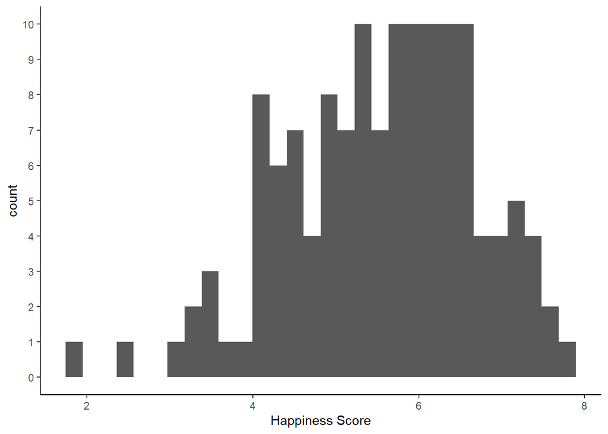

```r
ggplot(whr) +
  geom_histogram(aes(x = Ladder_score)) +
  labs(x = "Happiness Score") +
  scale_y_continuous(breaks = c(0:10)) +
  theme_classic()
```

Now, let’s plot happiness scores (`Ladder_score`) against `Social_support`. What can we see?

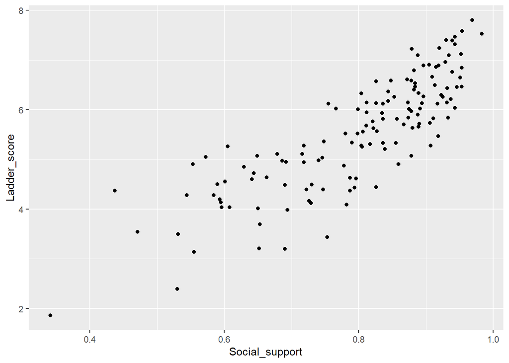

```r
ggplot(whr) +
  geom_point(aes(x = Social_support, y = Ladder_score))
```

## Model Building

Let’s run a simple model, and then check it’s summary.

```r
basic_model = lm(Ladder_score ~ Social_support, whr)

summary(basic_model)
```

```
Call:
lm(formula = Ladder_score ~ Social_support, data = whr)

Residuals:
     Min       1Q   Median       3Q      Max
-1.76562 -0.36701  0.01165  0.46577  1.49971

Coefficients:
               Estimate Std. Error t value Pr(>|t|)
(Intercept)     -0.3428     0.3386  -1.013    0.313
Social_support   7.3618     0.4183  17.599   <2e-16 ***
---
Signif. codes:  0 '***' 0.001 '**' 0.01 '*' 0.05 '.' 0.1 ' ' 1

Residual standard error: 0.6304 on 135 degrees of freedom
Multiple R-squared:  0.6964,    Adjusted R-squared:  0.6942
F-statistic: 309.7 on 1 and 135 DF,  p-value: < 2.2e-16
```

A one unit increase in Social Support is associated with a 7.4 increase in the happiness score. What is the maximum value the Happiness Score can take?

```r
max(whr$Ladder_score)
```

```
[1] 7.804
```

And now, let’s draw a histogram of the Social Support. So, how much does this model tell us?

```r
ggplot(whr) +
  ...(aes(x = Social_support))
```

Let’s correct the `Social_support` variable a bit, transforming it to 0-100 scale. What do you think about the model now? What do you think about $R^2$?

```r
whr = whr %>%
  mutate(Social_support_percentage = Social_support * 100)

adjusted_model = lm(Ladder_score ~ Social_support_percentage, whr)

summary(adjusted_model)
```

```
Call:
lm(formula = Ladder_score ~ Social_support_percentage, data = whr)

Residuals:
     Min       1Q   Median       3Q      Max
-1.76562 -0.36701  0.01165  0.46577  1.49971

Coefficients:
                           Estimate Std. Error t value Pr(>|t|)
(Intercept)               -0.342811   0.338568  -1.013    0.313
Social_support_percentage  0.073618   0.004183  17.599   <2e-16 ***
---
Signif. codes:  0 '***' 0.001 '**' 0.01 '*' 0.05 '.' 0.1 ' ' 1

Residual standard error: 0.6304 on 135 degrees of freedom
Multiple R-squared:  0.6964,    Adjusted R-squared:  0.6942
F-statistic: 309.7 on 1 and 135 DF,  p-value: < 2.2e-16
```

Let’s write this regression formula out. Do you remember the general form?

$$Y = \beta_0 + \beta_1X_1+\epsilon$$

In our case, this can be presented as

$$\text{Happines} = -0.34 + 0.07\text{ Social Support} + e$$

Alternatively,

$$Y = -0.34+0.07x+u$$

Now, visualize the regression.

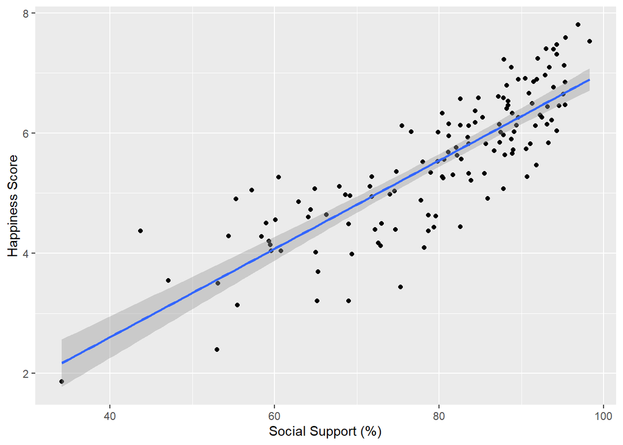

```r
ggplot(whr, aes(x = Social_support_percentage, y = Ladder_score)) +
  geom_point() +
  geom_smooth(method = "lm") +
  labs(x = "Social Support (%)",
       y = "Happiness Score")
```

## Diagnostics

Let’s analyze the regression. First, extract the residuals and plot their distribution. Does it follow $N(0, \sigma^2)$?

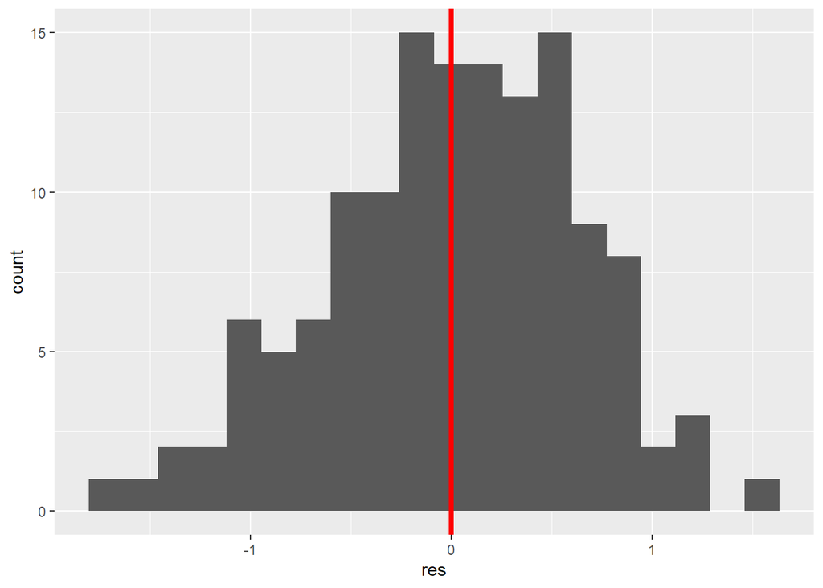

```r
res = adjusted_model$residuals

ggplot() +
  geom_histogram(aes(x = res), bins = 20) +
  geom_vline(xintercept = mean(res), color = "red", size = 1.5)
```

Now we need to check the constant variance assumption. Does it hold? What term is used to describe this satisfied assumption?

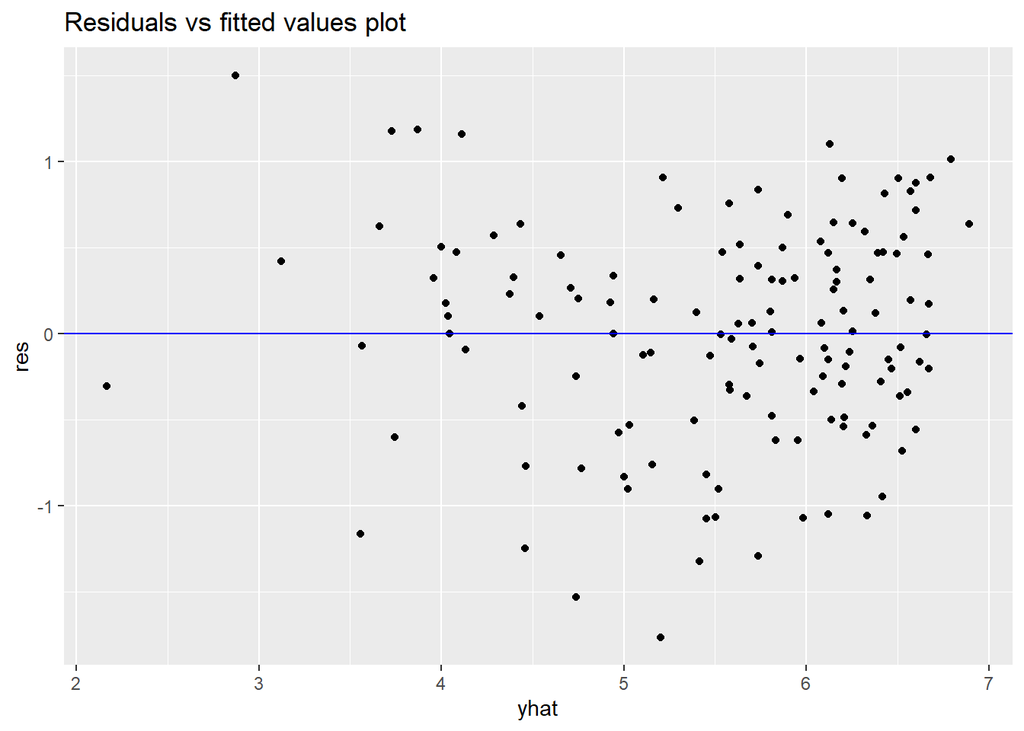

```r
yhat = adjusted_model$fitted.values

ggplot() +
  geom_point(aes(x = yhat, y = res)) +
  geom_hline(yintercept = 0, color = "blue") +
  labs(title = "Residuals vs fitted values plot")
```

Explore different patterns below

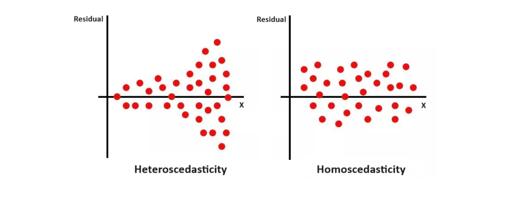

# Reporting Regression

This is a brief reminder on how you can present the regression output.

First, let’s load the library `modelsummary`.

```r
library(modelsummary)
```

Now, simply run the chunk below. Note the syntax. Let’s spend some time analyzing what’s going on. Compare it with `summary()`.

```r
summary(basic_model)
```

```
Call:
lm(formula = Ladder_score ~ Social_support, data = whr)

Residuals:
     Min       1Q   Median       3Q      Max
-1.76562 -0.36701  0.01165  0.46577  1.49971

Coefficients:
               Estimate Std. Error t value Pr(>|t|)
(Intercept)     -0.3428     0.3386  -1.013    0.313
Social_support   7.3618     0.4183  17.599   <2e-16 ***
---
Signif. codes:  0 '***' 0.001 '**' 0.01 '*' 0.05 '.' 0.1 ' ' 1

Residual standard error: 0.6304 on 135 degrees of freedom
Multiple R-squared:  0.6964,    Adjusted R-squared:  0.6942
F-statistic: 309.7 on 1 and 135 DF,  p-value: < 2.2e-16
```

```r
modelsummary(basic_model)
```

|  | (1) |
| --- | --- |
| (Intercept) | -0.343 |
|  | (0.339) |
| Social_support | 7.362 |
|  | (0.418) |
| Num.Obs. | 137 |
| R2 | 0.696 |
| R2 Adj. | 0.694 |
| AIC | 266.3 |
| BIC | 275.1 |
| Log.Lik. | -130.170 |
| F | 309.727 |
| RMSE | 0.63 |

We can present several models easily.

```r
modelsummary(list(basic_model, adjusted_model))
```

|  | (1) | (2) |
| --- | --- | --- |
| (Intercept) | -0.343 | -0.343 |
|  | (0.339) | (0.339) |
| Social_support | 7.362 |  |
|  | (0.418) |  |
| Social_support_percentage |  | 0.074 |
|  |  | (0.004) |
| Num.Obs. | 137 | 137 |
| R2 | 0.696 | 0.696 |
| R2 Adj. | 0.694 | 0.694 |
| AIC | 266.3 | 266.3 |
| BIC | 275.1 | 275.1 |
| Log.Lik. | -130.170 | -130.170 |
| F | 309.727 | 309.727 |
| RMSE | 0.63 | 0.63 |

Ok, there is a lot of things going on. Let’s customize the output so it presents only relevant information. Once again, pay attention to the syntax and the arguments.

- `coef_rename` renames the $\beta$ coefficient names
- `gof_omit` removes statistics, note that if you want to remove multiple statistics you should use `|`
- `stars = TRUE` indicates p-values stars

```r
modelsummary(list("Basic model" = basic_model,
                  "Adjusted model" = adjusted_model),
             coef_rename = c("Intercept",
                             "Social Support",
                             "Social Support (%)"),
             gof_omit = "BIC|AIC|RMSE|Log.Lik.",
             stars = TRUE)
```

|  | Basic model | Adjusted model |
| --- | --- | --- |
| Intercept | -0.343 | -0.343 |
|  | (0.339) | (0.339) |
| Social Support | 7.362*** |  |
|  | (0.418) |  |
| Social Support (%) |  | 0.074*** |
|  |  | (0.004) |
| Num.Obs. | 137 | 137 |
| R2 | 0.696 | 0.696 |
| R2 Adj. | 0.694 | 0.694 |
| F | 309.727 | 309.727 |

+ p < 0.1, * p < 0.05, ** p < 0.01, *** p < 0.001

# Exercises

Now we are working with healthy lifestyle (`Healthy_life_expectancy`) in the `whr` dataset. First, draw a histogram. What is the variable’s scale?

**Solution**

YOUR SOLUTION HERE

```r
...
```

Using `geom_vline()` add an average for `Healthy_life_expectancy` to the plot.

**Solution**

YOUR SOLUTION HERE

Insert a chunk below and build an `lm()` model where dependent variable is Happiness score (`Ladder_score`) and Independent variable is `Healthy_life_expectancy`. Present the summary.

**Solution**

YOUR SOLUTION HERE

Interpret coefficients and $R^2$.

**Solution**

YOUR SOLUTION HERE

Using $\LaTeX$ write out the regression function below.

**Solution**

$$\text{Happiness Score} = ...$$

Using `ggplot()` visualize plot Happiness score (`Ladder_score`) against `Healthy_life_expectancy`. Add a regression line.

**Solution**

```r
ggplot(...) +
  geom_...() +
  geom_smooth()
```

Extract the residuals from the model and plot their distribution.

**Solution**

YOUR SOLUTION HERE

Name X and Y axes. Title the plot. Add a `theme_bw()` to the plot.

**Solution**

YOUR SOLUTION HERE

Are residuals distributed approximately normally?

**Solution**

YOUR SOLUTION HERE

Draw residuals vs fitted plot. Is the data homoscedastic or heteroscedastic? Why?

**Solution**

YOUR SOLUTION HERE

Using `modelsummary()` present the regression output. Don’t forget to customize it.

**Solution**

YOUR SOLUTION HERE

# Check List

I know that wrong class of a variable can hinder statistical models and visualizations

I know how directories work and how to load data in R

I know how to calculate and visualize a simple regression

I know that I can adjust the scales of the variable to ease the interpretation

I know how access residuals of the model for the further diagnostics